# MachineLearning GLM

Carlos Grande Nuñez, Veronica Gomez Gomez y Pablo Olmos Martinez

13/02/2020

# GLM

La principal aportación de la regresión logística consiste en extener el modelo teórico de la regresión simple y multivariante, para aplicarla a problemas en los que la variable de salida del modelo es discreta o categórica, en lugar de continua.

### Objetivo de Negocio y Definición del Target

Nuestro objetivo de negocio es generar estructural departamentales y para ello necesitamos definir dos grandes grupos principalmente. Por un Lado buscamos los perfiles de casas de Alto Poder adquisitivo versus el Resto. Para ello nos apoyaremos de la Regresión Logística y necesitaremos definir un cluster 1/0 en el que las casas con valor 1 son aquellas de alto poder adquisitivo o Precio alto y 0 el resto de casas. ¿cómo definimos este punto de corte? Vamos a leer nuestra BBDD y estudiar la variable precio para encontrar el punto de corte óptimo para nuestro análisis

### Lectura de Nuestra Base cluster.

```r
#setwd("C:/Users/Pablo/Desktop/Machine_Learning_I/Z_PRACTICA_MACHINE_LEARNING/machineLearning1Process")
df_cluster <- read.csv ("../cluster.csv")
#setwd("C:/Users/Pablo/Desktop/Machine_Learning_I/Z_PRACTICA_MACHINE_LEARNING/machineLearning1Process")
df_root <- read.csv ("../kc_house_data.csv")


df_cluster$hclust=as.numeric(df_cluster$hclust)
df_cluster$cluster_final[df_cluster$hclust==2 | df_cluster$hclust==8] <- "top"
df_cluster$cluster_final[df_cluster$hclust==1 | df_cluster$hclust==5 | df_cluster$hclust==9] <- "low"
df_cluster$cluster_final[df_cluster$hclust==3 | df_cluster$hclust==4 | df_cluster$hclust==6 | df_cluster$hclust==7  ] <- "med"
```

## Density Price Plot de la variable Precio

Antes de plantear un punto de corte para crear una variable dicomtómica y estudiar un GLM plantearemos una Árbol de regression para estudiar el comportamiento de la variable Precio que tiene una distribucón de este estilo, no sigue una distribución normal. Parece una Gamma.

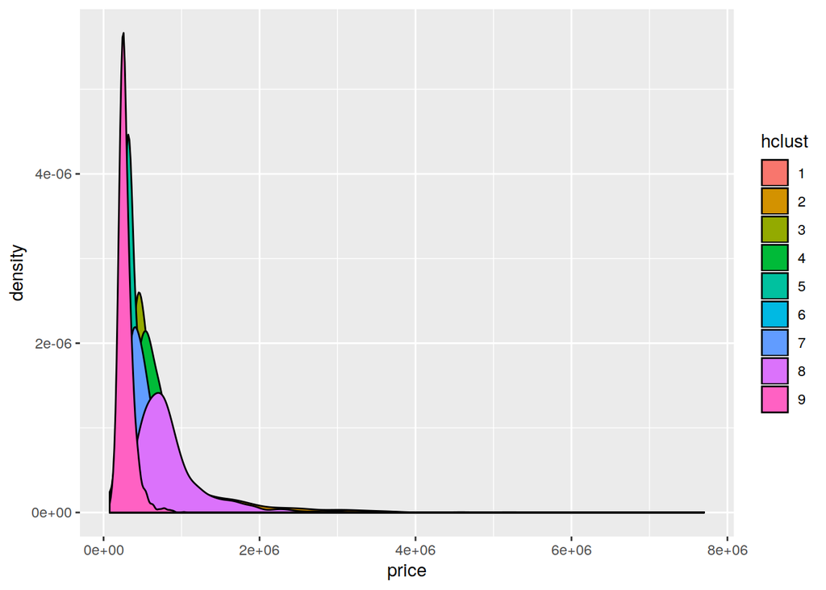

```r
df_cluster$hclust<-as.factor(df_cluster$hclust)
ggplot(data=df_cluster, aes(x=price, group=hclust ,fill=hclust)) +
    geom_density(adjust=1.5)
```

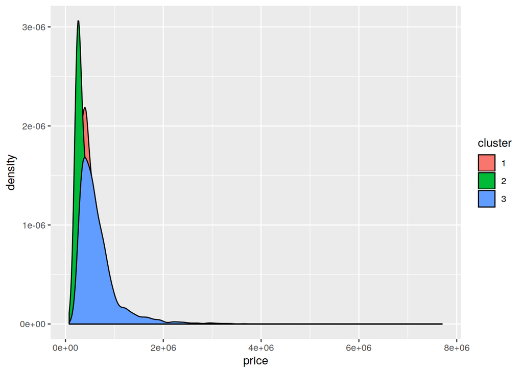

```r
df_cluster$cluster<-as.factor(df_cluster$cluster)
ggplot(data=df_cluster, aes(x=price, group=cluster ,fill=cluster)) +
    geom_density(adjust=1.5)
```

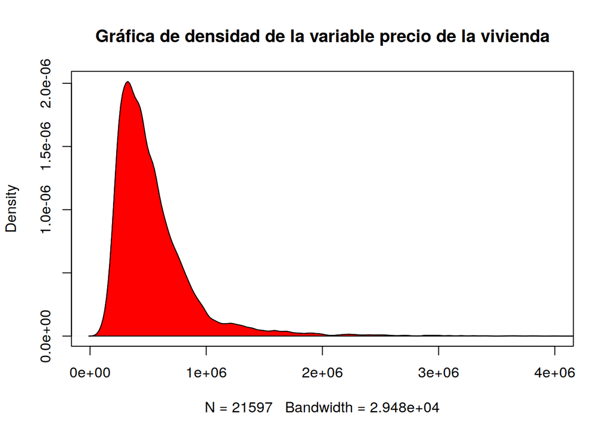

```r
densidad <- density(df_cluster$price)
plot(densidad, main="Gráfica de densidad de la variable precio de la vivienda" , xlim=c(0,4000000))
polygon(densidad, col="red")
```

```r
describe(df_cluster$price)
```

```
## df_cluster$price
##        n  missing distinct     Info     Mean      Gmd      .05      .10
##    21597        0     3622        1   540297   329526   210000   245000
##      .25      .50      .75      .90      .95
##   322000   450000   645000   887000  1160000
##
## lowest :   78000   80000   81000   82000   82500
## highest: 5350000 5570000 6890000 7060000 7700000
```

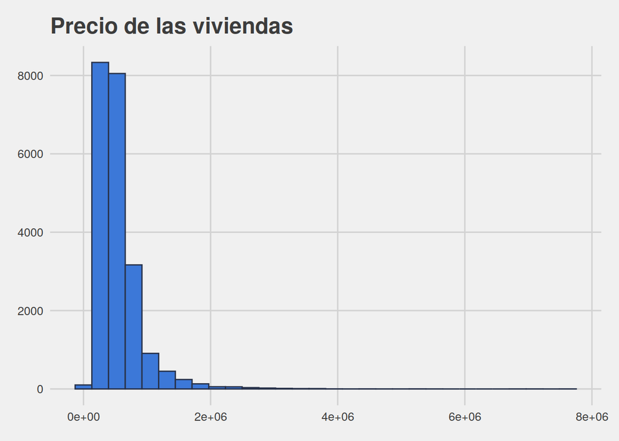

```r
histograma <- ggplot(df_cluster, aes(x=price)) +
  ggtitle("Precio de las viviendas") +
  theme_fivethirtyeight() +
  geom_histogram(color="#28324a", fill="#3c78d8")
histograma
```

Vemos que la distribución de la variable precio es muy asintótica hacia la derecha, es decir hay muchos valores extremos que puede que nos desvirtuen el análisis de la media, El punto de corte que vamos a determinar es el percentil 75 de la variable precio. La variable cluster será 1 cuando los precios sean mayores a percentil 75 de la variable precio y 0 en caso contrario

#### Contrucción de la variable Target

Vemos en el gráfico Box Plot que la distribución de la población cluster 1, las viviendas caras, tiene muchos valores extremos. Para realziar un buen análisis deberáimos extraerlos pero es importante para nuestro negocio por lo que vamos a mantenerlos a ver si somos capaces de realizar una buena predicción.

```r
target1 <- filter(df_cluster, price > 645000)
summary(target1)
```

```
##       X.2             X.1              X                 Y
##  Min.   :    6   Min.   :    6   Min.   :-29.306   Min.   :-28.849
##  1st Qu.: 5308   1st Qu.: 5308   1st Qu.:-12.556   1st Qu.:-16.927
##  Median :11034   Median :11034   Median : -6.444   Median : -5.068
##  Mean   :10972   Mean   :10972   Mean   : -6.725   Mean   : -3.355
##  3rd Qu.:16512   3rd Qu.:16512   3rd Qu.: -0.709   3rd Qu.:  9.205
##  Max.   :21591   Max.   :21591   Max.   : 27.464   Max.   : 29.774
##
##        id                   date          price            bedrooms
##  Min.   :1.200e+06   6/26/2014:  40   Min.   : 645500   Min.   : 1.000
##  1st Qu.:1.939e+09   6/20/2014:  39   1st Qu.: 723500   1st Qu.: 3.000
##  Median :3.886e+09   3/25/2015:  37   Median : 826000   Median : 4.000
##  Mean   :4.509e+09   4/23/2015:  37   Mean   : 987839   Mean   : 3.824
##  3rd Qu.:7.301e+09   7/14/2014:  37   3rd Qu.:1050000   3rd Qu.: 4.000
##  Max.   :9.839e+09   4/27/2015:  36   Max.   :7700000   Max.   :10.000
##                      (Other)  :5145
##    bathrooms      sqft_living       sqft_lot           floors
##  Min.   :0.750   Min.   :  890   Min.   :    520   Min.   :1.000
##  1st Qu.:2.250   1st Qu.: 2330   1st Qu.:   5400   1st Qu.:1.000
##  Median :2.500   Median : 2880   Median :   8580   Median :2.000
##  Mean   :2.675   Mean   : 2999   Mean   :  21363   Mean   :1.713
##  3rd Qu.:3.250   3rd Qu.: 3510   3rd Qu.:  14348   3rd Qu.:2.000
##  Max.   :8.000   Max.   :13540   Max.   :1651359   Max.   :3.500
##
##    waterfront           view          condition         grade
##  Min.   :0.00000   Min.   :0.0000   Min.   :1.000   Min.   : 5.000
##  1st Qu.:0.00000   1st Qu.:0.0000   1st Qu.:3.000   1st Qu.: 8.000
##  Median :0.00000   Median :0.0000   Median :3.000   Median : 9.000
##  Mean   :0.02514   Mean   :0.6258   Mean   :3.462   Mean   : 8.844
##  3rd Qu.:0.00000   3rd Qu.:0.0000   3rd Qu.:4.000   3rd Qu.:10.000
##  Max.   :1.00000   Max.   :4.0000   Max.   :5.000   Max.   :13.000
##
##    sqft_above   sqft_basement       yr_built     yr_renovated
##  Min.   : 580   Min.   :   0.0   Min.   :1900   Min.   :   0.0
##  1st Qu.:1760   1st Qu.:   0.0   1st Qu.:1951   1st Qu.:   0.0
##  Median :2430   Median :   0.0   Median :1981   Median :   0.0
##  Mean   :2534   Mean   : 464.9   Mean   :1973   Mean   : 158.2
##  3rd Qu.:3160   3rd Qu.: 890.0   3rd Qu.:2001   3rd Qu.:   0.0
##  Max.   :9410   Max.   :4820.0   Max.   :2015   Max.   :2015.0
##
##     zipcode           lat             long        sqft_living15
##  Min.   :98001   Min.   :47.16   Min.   :-122.5   Min.   : 860
##  1st Qu.:98033   1st Qu.:47.57   1st Qu.:-122.3   1st Qu.:2020
##  Median :98074   Median :47.63   Median :-122.2   Median :2570
##  Mean   :98074   Mean   :47.62   Mean   :-122.2   Mean   :2619
##  3rd Qu.:98115   3rd Qu.:47.67   3rd Qu.:-122.1   3rd Qu.:3130
##  Max.   :98199   Max.   :47.78   Max.   :-121.7   Max.   :6210
##
##    sqft_lot15     cluster      hclust     Cluster_final cluster_final
##  Min.   :   967   1:1461   8      :1550   low: 977      Length:5371
##  1st Qu.:  5250   2: 687   1      : 849   med:2319      Class :character
##  Median :  8416   3:3223   3      : 750   top:2075      Mode  :character
##  Mean   : 16300            4      : 627
##  3rd Qu.: 12912            2      : 525
##  Max.   :871200            7      : 496
##                            (Other): 574
```

```r
target0 <- filter(df_cluster, price <= 645000)
summary(target0)
```

```
##       X.2             X.1              X                 Y
##  Min.   :    1   Min.   :    1   Min.   :-30.601   Min.   :-28.717
##  1st Qu.: 5418   1st Qu.: 5418   1st Qu.: -4.623   1st Qu.:-10.053
##  Median :10720   Median :10720   Median :  2.784   Median :  1.745
##  Mean   :10742   Mean   :10742   Mean   :  2.226   Mean   :  1.110
##  3rd Qu.:16089   3rd Qu.:16089   3rd Qu.: 11.198   3rd Qu.: 11.682
##  Max.   :21597   Max.   :21597   Max.   : 27.537   Max.   : 30.132
##
##        id                   date           price           bedrooms
##  Min.   :1.000e+06   6/23/2014:  111   Min.   : 78000   Min.   : 1.000
##  1st Qu.:2.155e+09   6/25/2014:   95   1st Qu.:290000   1st Qu.: 3.000
##  Median :3.905e+09   8/26/2014:   94   Median :385000   Median : 3.000
##  Mean   :4.604e+09   7/8/2014 :   93   Mean   :392154   Mean   : 3.224
##  3rd Qu.:7.312e+09   4/14/2015:   92   3rd Qu.:491838   3rd Qu.: 4.000
##  Max.   :9.900e+09   4/22/2015:   91   Max.   :645000   Max.   :33.000
##                      (Other)  :15650
##    bathrooms      sqft_living      sqft_lot           floors
##  Min.   :0.500   Min.   : 370   Min.   :    572   Min.   :1.000
##  1st Qu.:1.500   1st Qu.:1310   1st Qu.:   5000   1st Qu.:1.000
##  Median :2.000   Median :1700   Median :   7450   Median :1.000
##  Mean   :1.931   Mean   :1776   Mean   :  13026   Mean   :1.422
##  3rd Qu.:2.500   3rd Qu.:2160   3rd Qu.:   9950   3rd Qu.:2.000
##  Max.   :7.500   Max.   :5461   Max.   :1164794   Max.   :3.500
##
##    waterfront            view          condition         grade
##  Min.   :0.000000   Min.   :0.0000   Min.   :1.000   Min.   : 3.000
##  1st Qu.:0.000000   1st Qu.:0.0000   1st Qu.:3.000   1st Qu.: 7.000
##  Median :0.000000   Median :0.0000   Median :3.000   Median : 7.000
##  Mean   :0.001726   Mean   :0.1047   Mean   :3.393   Mean   : 7.265
##  3rd Qu.:0.000000   3rd Qu.:0.0000   3rd Qu.:4.000   3rd Qu.: 8.000
##  Max.   :1.000000   Max.   :4.0000   Max.   :5.000   Max.   :11.000
##
##    sqft_above   sqft_basement       yr_built     yr_renovated
##  Min.   : 370   Min.   :   0.0   Min.   :1900   Min.   :   0.00
##  1st Qu.:1120   1st Qu.:   0.0   1st Qu.:1952   1st Qu.:   0.00
##  Median :1400   Median :   0.0   Median :1972   Median :   0.00
##  Mean   :1542   Mean   : 234.4   Mean   :1970   Mean   :  60.06
##  3rd Qu.:1850   3rd Qu.: 450.0   3rd Qu.:1994   3rd Qu.:   0.00
##  Max.   :5450   Max.   :2196.0   Max.   :2015   Max.   :2015.00
##
##     zipcode           lat             long        sqft_living15
##  Min.   :98001   Min.   :47.16   Min.   :-122.5   Min.   : 399
##  1st Qu.:98032   1st Qu.:47.42   1st Qu.:-122.3   1st Qu.:1410
##  Median :98065   Median :47.54   Median :-122.3   Median :1690
##  Mean   :98079   Mean   :47.54   Mean   :-122.2   Mean   :1777
##  3rd Qu.:98118   3rd Qu.:47.68   3rd Qu.:-122.1   3rd Qu.:2080
##  Max.   :98199   Max.   :47.78   Max.   :-121.3   Max.   :4362
##
##    sqft_lot15     cluster      hclust     Cluster_final cluster_final
##  Min.   :   651   1:5794   1      :3781   low:8993      Length:16226
##  1st Qu.:  5066   2:5000   9      :3079   med:5906      Class :character
##  Median :  7500   3:5432   5      :2133   top:1327      Mode  :character
##  Mean   : 11586            3      :2109
##  3rd Qu.:  9600            7      :1466
##  Max.   :438213            6      :1344
##                            (Other):2314
```

```r
df_cluster$cluster=as.numeric(df_cluster$hclust)


df_cluster$target[df_cluster$price> 645000] <- '1'
df_cluster$target[df_cluster$price<= 645000] <- '0'

table(df_cluster$target)
```

```
##
##     0     1
## 16226  5371
```

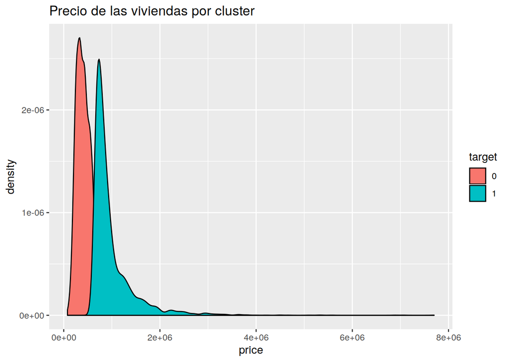

```r
df_cluster$cluster<-as.factor(df_cluster$target)
ggplot(data=df_cluster, aes(x=price, group=target ,fill=target)) +
  ggtitle("Precio de las viviendas por cluster") +
    geom_density(adjust=1.5)
```

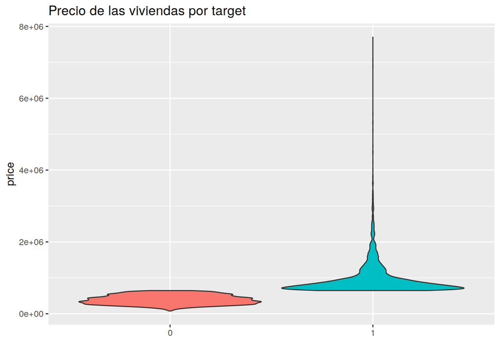

```r
 df_cluster %>%
  ggplot( aes(x=target, y=price, fill=target)) +
    ggtitle("Precio de las viviendas por target") +
    geom_violin() +
    xlab("class") +
    theme(legend.position="none") +
    xlab("")
```

## EDA por cluster Vamos a realizar un análisis descriptivo de las variables en función del cluster

#### Descripcion de las variables

- id: valor único (Primary key).
- date: fecha de venta de la vivienda.
- price: precio de venta. Variable seleccionada para la aplicación del modelo y su posterior predicción.
- bedrooms: número de habitaciones por vivienda.
- bathrooms: número de baños por vivienda.
- sqft_living: superficie de la vivienda en pies cuadrados (superficie escriturada).
- sqft_lot: superficie de la parcela de la vivienda en pies cuadrados (superficie parcelaria).
- floors: número de plantas por vivienda.
- waterfront: si la vivienda tiene vistas al mar.
- view: el número de veces que se ha visitado la vivienda desde su puesta en venta.
- condition*: el estado de la vivienda establecido mediante una variable numérica del 1 al 5.
- grade*: nota general de la vivienda propuesta por el sistema de puntuación de la zona del 1 al 13.
- sqft_above: superficie de la huella perimetral de la vivienda sobre rasante en pies cuadrados.
- sqft_basement: superficie de la vivienda bajo rasante en piés cuadrados
- yr_built: año de construcción de la vivienda
- yr_renovated: año de la renovación de la vivienda. En caso de no haber sido renovada este parámetro se ha igualado a 0.
- zipcode: codigo postal de la vivienda.
- lat: latitud de la coordenada de la vivienda medida en pies.
- long: longitud de la coordenada de la vivienda medida en pies.
- sqft_living15: superficie de la vivienda en el año 2015 (admite renovaciones).
- sqft_lot15: superficie de la parcela en el año 2015 (admite modificaciones)

# Análisis Exploratorio de las Variables

```r
df_target_1 = filter(df_cluster, target == "1")
#Muestra de las primeras 5 filas de la base de datos
kable(head(df_target_1)) %>%
  kable_styling() %>%
  scroll_box(width = "100%", height = TRUE)
```

| X.2 | X.1 | X | Y | id | date | price | bedrooms | bathrooms | sqft_living | sqft_lot | floors | waterfront | view | condition | grade | sqft_above | sqft_basement | yr_built | yr_renovated | zipcode | lat | long | sqft_living15 | sqft_lot15 | cluster | hclust | Cluster_final | cluster_final | target |
| --- | --- | --- | --- | --- | --- | --- | --- | --- | --- | --- | --- | --- | --- | --- | --- | --- | --- | --- | --- | --- | --- | --- | --- | --- | --- | --- | --- | --- | --- |
| 6 | 6 | -2.654252 | -26.7202890 | 7237550310 | 5/12/2014 | 1230000 | 4 | 4.50 | 5420 | 101930 | 1.0 | 0 | 0 | 3 | 11 | 3890 | 1530 | 2001 | 0 | 98053 | 47.6561 | -122.005 | 4760 | 101930 | 1 | 4 | med | med | 1 |
| 11 | 11 | 8.887572 | -0.5260397 | 1736800520 | 4/3/2015 | 662500 | 3 | 2.50 | 3560 | 9796 | 1.0 | 0 | 0 | 3 | 8 | 1860 | 1700 | 1965 | 0 | 98007 | 47.6007 | -122.145 | 2210 | 8925 | 1 | 3 | med | med | 1 |
| 16 | 16 | -12.593827 | -1.7041182 | 9297300055 | 1/24/2015 | 650000 | 4 | 3.00 | 2950 | 5000 | 2.0 | 0 | 3 | 3 | 9 | 1980 | 970 | 1979 | 0 | 98126 | 47.5714 | -122.375 | 2140 | 4000 | 1 | 7 | med | med | 1 |
| 22 | 22 | -5.461244 | -0.5643586 | 2524049179 | 8/26/2014 | 2000000 | 3 | 2.75 | 3050 | 44867 | 1.0 | 0 | 4 | 3 | 9 | 2330 | 720 | 1968 | 0 | 98040 | 47.5316 | -122.233 | 4110 | 20336 | 1 | 3 | med | med | 1 |
| 27 | 27 | -11.462589 | 22.0585529 | 1794500383 | 6/26/2014 | 937000 | 3 | 1.75 | 2450 | 2691 | 2.0 | 0 | 0 | 3 | 8 | 1750 | 700 | 1915 | 0 | 98119 | 47.6386 | -122.360 | 1760 | 3573 | 1 | 1 | low | low | 1 |
| 28 | 28 | -7.759261 | 24.3302470 | 3303700376 | 12/1/2014 | 667000 | 3 | 1.00 | 1400 | 1581 | 1.5 | 0 | 0 | 5 | 8 | 1400 | 0 | 1909 | 0 | 98112 | 47.6221 | -122.314 | 1860 | 3861 | 1 | 1 | low | low | 1 |

```r
#Tabla resumen con los principales estadísticos
kable(summary(df_target_1)) %>%
  kable_styling() %>%
  scroll_box(width = "100%", height = TRUE)
```

|  | X.2 | X.1 | X | Y | id | date | price | bedrooms | bathrooms | sqft_living | sqft_lot | floors | waterfront | view | condition | grade | sqft_above | sqft_basement | yr_built | yr_renovated | zipcode | lat | long | sqft_living15 | sqft_lot15 | cluster | hclust | Cluster_final | cluster_final | … |
| --- | --- | --- | --- | --- | --- | --- | --- | --- | --- | --- | --- | --- | --- | --- | --- | --- | --- | --- | --- | --- | --- | --- | --- | --- | --- | --- | --- | --- | --- | --- |
|  | Min. : 6 | Min. : 6 | Min. :-29.306 | Min. :-28.849 | Min. :1.200e+06 | 6/26/2014: 40 | Min. : 645500 | Min. : 1.000 | Min. :0.750 | Min. : 890 | Min. : 520 | Min. :1.000 | Min. :0.00000 | Min. :0.0000 | Min. :1.000 | Min. : 5.000 | Min. : 580 | Min. : 0.0 | Min. :1900 | Min. : 0.0 | Min. :98001 | Min. :47.16 | Min. :-122.5 | Min. : 860 | Min. : 967 | 0: 0 | 8 :1550 | low: 977 | Length:5371 | … |
|  | 1st Qu.: 5308 | 1st Qu.: 5308 | 1st Qu.:-12.556 | 1st Qu.:-16.927 | 1st Qu.:1.939e+09 | 6/20/2014: 39 | 1st Qu.: 723500 | 1st Qu.: 3.000 | 1st Qu.:2.250 | 1st Qu.: 2330 | 1st Qu.: 5400 | 1st Qu.:1.000 | 1st Qu.:0.00000 | 1st Qu.:0.0000 | 1st Qu.:3.000 | 1st Qu.: 8.000 | 1st Qu.:1760 | 1st Qu.: 0.0 | 1st Qu.:1951 | 1st Qu.: 0.0 | 1st Qu.:98033 | 1st Qu.:47.57 | 1st Qu.:-122.3 | 1st Qu.:2020 | 1st Qu.: 5250 | 1:5371 | 1 : 849 | med:2319 | Class :character | … |
|  | Median :11034 | Median :11034 | Median : -6.444 | Median : -5.068 | Median :3.886e+09 | 3/25/2015: 37 | Median : 826000 | Median : 4.000 | Median :2.500 | Median : 2880 | Median : 8580 | Median :2.000 | Median :0.00000 | Median :0.0000 | Median :3.000 | Median : 9.000 | Median :2430 | Median : 0.0 | Median :1981 | Median : 0.0 | Median :98074 | Median :47.63 | Median :-122.2 | Median :2570 | Median : 8416 | NA | 3 : 750 | top:2075 | Mode :character | … |
|  | Mean :10972 | Mean :10972 | Mean : -6.725 | Mean : -3.355 | Mean :4.509e+09 | 4/23/2015: 37 | Mean : 987839 | Mean : 3.824 | Mean :2.675 | Mean : 2999 | Mean : 21363 | Mean :1.713 | Mean :0.02514 | Mean :0.6258 | Mean :3.462 | Mean : 8.844 | Mean :2534 | Mean : 464.9 | Mean :1973 | Mean : 158.2 | Mean :98074 | Mean :47.62 | Mean :-122.2 | Mean :2619 | Mean : 16300 | NA | 4 : 627 | NA | NA | … |
|  | 3rd Qu.:16512 | 3rd Qu.:16512 | 3rd Qu.: -0.709 | 3rd Qu.: 9.205 | 3rd Qu.:7.301e+09 | 7/14/2014: 37 | 3rd Qu.:1050000 | 3rd Qu.: 4.000 | 3rd Qu.:3.250 | 3rd Qu.: 3510 | 3rd Qu.: 14348 | 3rd Qu.:2.000 | 3rd Qu.:0.00000 | 3rd Qu.:0.0000 | 3rd Qu.:4.000 | 3rd Qu.:10.000 | 3rd Qu.:3160 | 3rd Qu.: 890.0 | 3rd Qu.:2001 | 3rd Qu.: 0.0 | 3rd Qu.:98115 | 3rd Qu.:47.67 | 3rd Qu.:-122.1 | 3rd Qu.:3130 | 3rd Qu.: 12912 | NA | 2 : 525 | NA | NA | … |
|  | Max. :21591 | Max. :21591 | Max. : 27.464 | Max. : 29.774 | Max. :9.839e+09 | 4/27/2015: 36 | Max. :7700000 | Max. :10.000 | Max. :8.000 | Max. :13540 | Max. :1651359 | Max. :3.500 | Max. :1.00000 | Max. :4.0000 | Max. :5.000 | Max. :13.000 | Max. :9410 | Max. :4820.0 | Max. :2015 | Max. :2015.0 | Max. :98199 | Max. :47.78 | Max. :-121.7 | Max. :6210 | Max. :871200 | NA | 7 : 496 | NA | NA | … |
|  | NA | NA | NA | NA | NA | (Other) :5145 | NA | NA | NA | NA | NA | NA | NA | NA | NA | NA | NA | NA | NA | NA | NA | NA | NA | NA | NA | NA | (Other): 574 | NA | NA | … |

```r
df_target_0 = filter(df_cluster, target == "0")
#Muestra de las primeras 5 filas de la base de datos
kable(head(df_target_0)) %>%
  kable_styling() %>%
  scroll_box(width = "100%", height = TRUE)
```

| X.2 | X.1 | X | Y | id | date | price | bedrooms | bathrooms | sqft_living | sqft_lot | floors | waterfront | view | condition | grade | sqft_above | sqft_basement | yr_built | yr_renovated | zipcode | lat | long | sqft_living15 | sqft_lot15 | cluster | hclust | Cluster_final | cluster_final | target |
| --- | --- | --- | --- | --- | --- | --- | --- | --- | --- | --- | --- | --- | --- | --- | --- | --- | --- | --- | --- | --- | --- | --- | --- | --- | --- | --- | --- | --- | --- |
| 1 | 1 | 3.7621642 | 22.445021 | 7129300520 | 10/13/2014 | 221900 | 3 | 1.00 | 1180 | 5650 | 1 | 0 | 0 | 3 | 7 | 1180 | 0 | 1955 | 0 | 98178 | 47.5112 | -122.257 | 1340 | 5650 | 0 | 1 | low | low | 0 |
| 2 | 2 | -24.0359753 | 9.766915 | 6414100192 | 12/9/2014 | 538000 | 3 | 2.25 | 2570 | 7242 | 2 | 0 | 0 | 3 | 7 | 2170 | 400 | 1951 | 1991 | 98125 | 47.7210 | -122.319 | 1690 | 7639 | 0 | 2 | top | top | 0 |
| 3 | 3 | 5.2170153 | 8.102678 | 5631500400 | 2/25/2015 | 180000 | 2 | 1.00 | 770 | 10000 | 1 | 0 | 0 | 3 | 6 | 770 | 0 | 1933 | 0 | 98028 | 47.7379 | -122.233 | 2720 | 8062 | 0 | 3 | med | med | 0 |
| 4 | 4 | 7.5887297 | 18.967730 | 2487200875 | 12/9/2014 | 604000 | 4 | 3.00 | 1960 | 5000 | 1 | 0 | 0 | 5 | 7 | 1050 | 910 | 1965 | 0 | 98136 | 47.5208 | -122.393 | 1360 | 5000 | 0 | 1 | low | low | 0 |
| 5 | 5 | 0.6661815 | 3.939548 | 1954400510 | 2/18/2015 | 510000 | 3 | 2.00 | 1680 | 8080 | 1 | 0 | 0 | 3 | 8 | 1680 | 0 | 1987 | 0 | 98074 | 47.6168 | -122.045 | 1800 | 7503 | 0 | 3 | med | med | 0 |
| 7 | 7 | 15.5619202 | -13.926208 | 1321400060 | 6/27/2014 | 257500 | 3 | 2.25 | 1715 | 6819 | 2 | 0 | 0 | 3 | 7 | 1715 | 0 | 1995 | 0 | 98003 | 47.3097 | -122.327 | 2238 | 6819 | 0 | 5 | low | low | 0 |

```r
#Tabla resumen con los principales estadísticos
kable(summary(df_target_0)) %>%
  kable_styling() %>%
  scroll_box(width = "100%", height = TRUE)
```

|  | X.2 | X.1 | X | Y | id | date | price | bedrooms | bathrooms | sqft_living | sqft_lot | floors | waterfront | view | condition | grade | sqft_above | sqft_basement | yr_built | yr_renovated | zipcode | lat | long | sqft_living15 | sqft_lot15 | cluster | hclust | Cluster_final | cluster_final | … |
| --- | --- | --- | --- | --- | --- | --- | --- | --- | --- | --- | --- | --- | --- | --- | --- | --- | --- | --- | --- | --- | --- | --- | --- | --- | --- | --- | --- | --- | --- | --- |
|  | Min. : 1 | Min. : 1 | Min. :-30.601 | Min. :-28.717 | Min. :1.000e+06 | 6/23/2014: 111 | Min. : 78000 | Min. : 1.000 | Min. :0.500 | Min. : 370 | Min. : 572 | Min. :1.000 | Min. :0.000000 | Min. :0.0000 | Min. :1.000 | Min. : 3.000 | Min. : 370 | Min. : 0.0 | Min. :1900 | Min. : 0.00 | Min. :98001 | Min. :47.16 | Min. :-122.5 | Min. : 399 | Min. : 651 | 0:16226 | 1 :3781 | low:8993 | Length:16226 | … |
|  | 1st Qu.: 5418 | 1st Qu.: 5418 | 1st Qu.: -4.623 | 1st Qu.:-10.053 | 1st Qu.:2.155e+09 | 6/25/2014: 95 | 1st Qu.:290000 | 1st Qu.: 3.000 | 1st Qu.:1.500 | 1st Qu.:1310 | 1st Qu.: 5000 | 1st Qu.:1.000 | 1st Qu.:0.000000 | 1st Qu.:0.0000 | 1st Qu.:3.000 | 1st Qu.: 7.000 | 1st Qu.:1120 | 1st Qu.: 0.0 | 1st Qu.:1952 | 1st Qu.: 0.00 | 1st Qu.:98032 | 1st Qu.:47.42 | 1st Qu.:-122.3 | 1st Qu.:1410 | 1st Qu.: 5066 | 1: 0 | 9 :3079 | med:5906 | Class :character | … |
|  | Median :10720 | Median :10720 | Median : 2.784 | Median : 1.745 | Median :3.905e+09 | 8/26/2014: 94 | Median :385000 | Median : 3.000 | Median :2.000 | Median :1700 | Median : 7450 | Median :1.000 | Median :0.000000 | Median :0.0000 | Median :3.000 | Median : 7.000 | Median :1400 | Median : 0.0 | Median :1972 | Median : 0.00 | Median :98065 | Median :47.54 | Median :-122.3 | Median :1690 | Median : 7500 | NA | 5 :2133 | top:1327 | Mode :character | … |
|  | Mean :10742 | Mean :10742 | Mean : 2.226 | Mean : 1.110 | Mean :4.604e+09 | 7/8/2014 : 93 | Mean :392154 | Mean : 3.224 | Mean :1.931 | Mean :1776 | Mean : 13026 | Mean :1.422 | Mean :0.001726 | Mean :0.1047 | Mean :3.393 | Mean : 7.265 | Mean :1542 | Mean : 234.4 | Mean :1970 | Mean : 60.06 | Mean :98079 | Mean :47.54 | Mean :-122.2 | Mean :1777 | Mean : 11586 | NA | 3 :2109 | NA | NA | … |
|  | 3rd Qu.:16089 | 3rd Qu.:16089 | 3rd Qu.: 11.198 | 3rd Qu.: 11.682 | 3rd Qu.:7.312e+09 | 4/14/2015: 92 | 3rd Qu.:491838 | 3rd Qu.: 4.000 | 3rd Qu.:2.500 | 3rd Qu.:2160 | 3rd Qu.: 9950 | 3rd Qu.:2.000 | 3rd Qu.:0.000000 | 3rd Qu.:0.0000 | 3rd Qu.:4.000 | 3rd Qu.: 8.000 | 3rd Qu.:1850 | 3rd Qu.: 450.0 | 3rd Qu.:1994 | 3rd Qu.: 0.00 | 3rd Qu.:98118 | 3rd Qu.:47.68 | 3rd Qu.:-122.1 | 3rd Qu.:2080 | 3rd Qu.: 9600 | NA | 7 :1466 | NA | NA | … |
|  | Max. :21597 | Max. :21597 | Max. : 27.537 | Max. : 30.132 | Max. :9.900e+09 | 4/22/2015: 91 | Max. :645000 | Max. :33.000 | Max. :7.500 | Max. :5461 | Max. :1164794 | Max. :3.500 | Max. :1.000000 | Max. :4.0000 | Max. :5.000 | Max. :11.000 | Max. :5450 | Max. :2196.0 | Max. :2015 | Max. :2015.00 | Max. :98199 | Max. :47.78 | Max. :-121.3 | Max. :4362 | Max. :438213 | NA | 6 :1344 | NA | NA | … |
|  | NA | NA | NA | NA | NA | (Other) :15650 | NA | NA | NA | NA | NA | NA | NA | NA | NA | NA | NA | NA | NA | NA | NA | NA | NA | NA | NA | NA | (Other):2314 | NA | NA | … |

**Estudio de la variable “price” (precio de venta).**

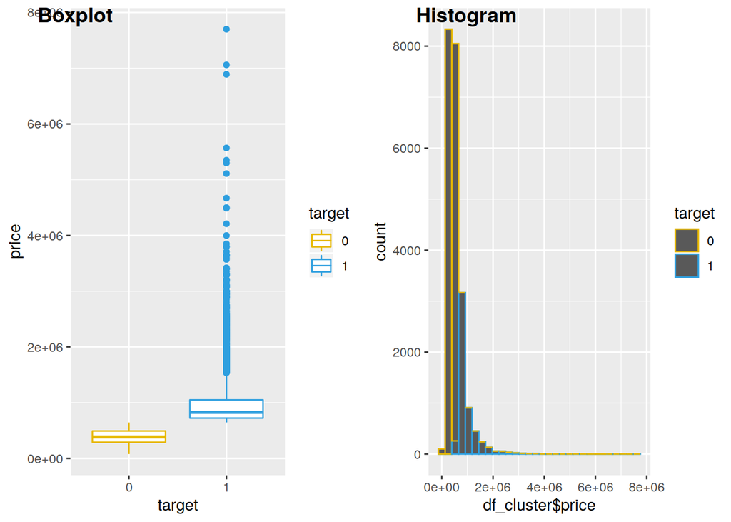

```r
my3cols <- c("#E7B800", "#2E9FDF", "#FC4E07")
df_cluster$target <- as.factor(df_cluster$target)
pBoxPlot <- ggplot(df_cluster, aes(x = target, y = price))
bxp <- pBoxPlot + geom_boxplot(aes(color = target)) +
  scale_color_manual(values = my3cols)
geomHist <- ggplot(data=df_cluster, aes(df_cluster$price))
gh <- geomHist + geom_histogram(aes(color = target)) +
      scale_color_manual(values = my3cols)
figure <- ggarrange(bxp, gh,
                    labels = c("Boxplot", "Histogram"),
                    ncol = 2, nrow = 1)
figure
```

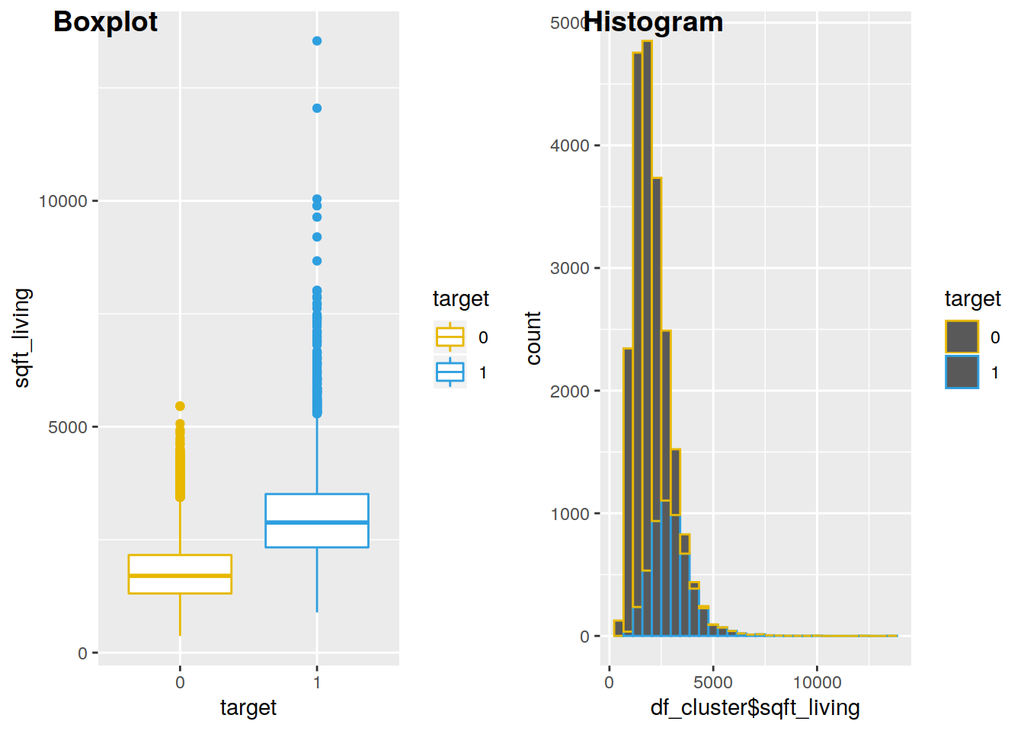

```r
my3cols <- c("#E7B800", "#2E9FDF", "#FC4E07")
df_cluster$target <- as.factor(df_cluster$target)
pBoxPlot <- ggplot(df_cluster, aes(x = target, y = sqft_living))
bxp <- pBoxPlot + geom_boxplot(aes(color = target)) +
  scale_color_manual(values = my3cols)
geomHist <- ggplot(data=df_cluster, aes(df_cluster$sqft_living))
gh <- geomHist + geom_histogram(aes(color = target)) +
      scale_color_manual(values = my3cols)
figure <- ggarrange(bxp, gh,
                    labels = c("Boxplot", "Histogram"),
                    ncol = 2, nrow = 1)
figure
```

Variable “sqft_lot15”: superficie de la parcela en el año 2015

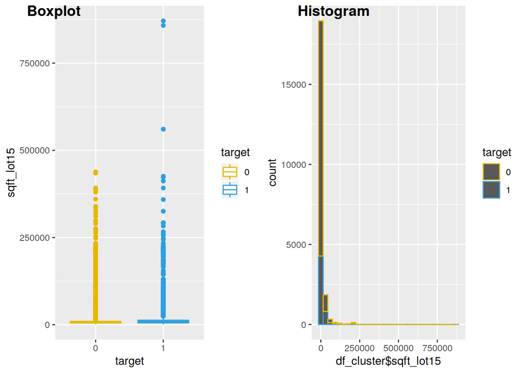

```r
my3cols <- c("#E7B800", "#2E9FDF", "#FC4E07")
df_cluster$target <- as.factor(df_cluster$target)
pBoxPlot <- ggplot(df_cluster, aes(x = target, y = sqft_lot15))
bxp <- pBoxPlot + geom_boxplot(aes(color = target)) +
  scale_color_manual(values = my3cols)
geomHist <- ggplot(data=df_cluster, aes(df_cluster$sqft_lot15))
gh <- geomHist + geom_histogram(aes(color = target)) +
      scale_color_manual(values = my3cols)
figure <- ggarrange(bxp, gh,
                    labels = c("Boxplot", "Histogram"),
                    ncol = 2, nrow = 1)
figure
```

**Estudio de la variable “sqft_above” (superficie de la huella de la vivienda).**

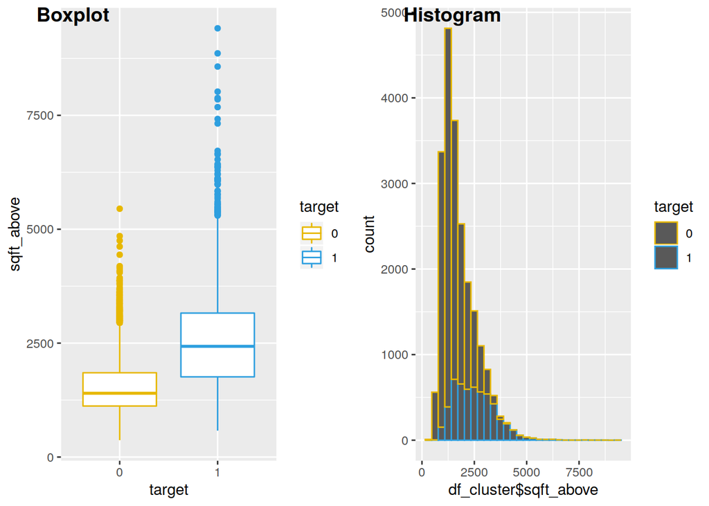

```r
my3cols <- c("#E7B800", "#2E9FDF", "#FC4E07")
df_cluster$target <- as.factor(df_cluster$target)
pBoxPlot <- ggplot(df_cluster, aes(x = target, y = sqft_above))
bxp <- pBoxPlot + geom_boxplot(aes(color = target)) +
  scale_color_manual(values = my3cols)
geomHist <- ggplot(data=df_cluster, aes(df_cluster$sqft_above))
gh <- geomHist + geom_histogram(aes(color = target)) +
      scale_color_manual(values = my3cols)
figure <- ggarrange(bxp, gh,
                    labels = c("Boxplot", "Histogram"),
                    ncol = 2, nrow = 1)
figure
```

**Estudio de la variable “sqft_basement” (superficie bajo rasante).**

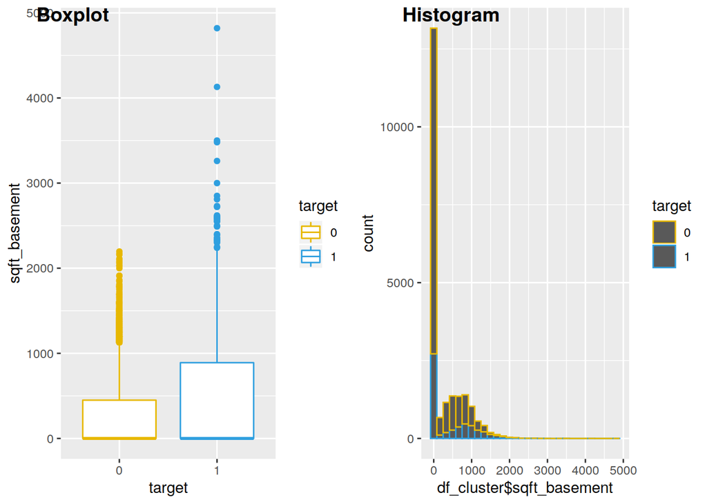

```r
my3cols <- c("#E7B800", "#2E9FDF", "#FC4E07")
df_cluster$target <- as.factor(df_cluster$target)
pBoxPlot <- ggplot(df_cluster, aes(x = target, y = sqft_basement))
bxp <- pBoxPlot + geom_boxplot(aes(color = target)) +
  scale_color_manual(values = my3cols)
geomHist <- ggplot(data=df_cluster, aes(df_cluster$sqft_basement))
gh <- geomHist + geom_histogram(aes(color = target)) +
      scale_color_manual(values = my3cols)
figure <- ggarrange(bxp, gh,
                    labels = c("Boxplot", "Histogram"),
                    ncol = 2, nrow = 1)
figure
```

**Estudio de la variable “yr_built” (año de construcción de la vivienda).**

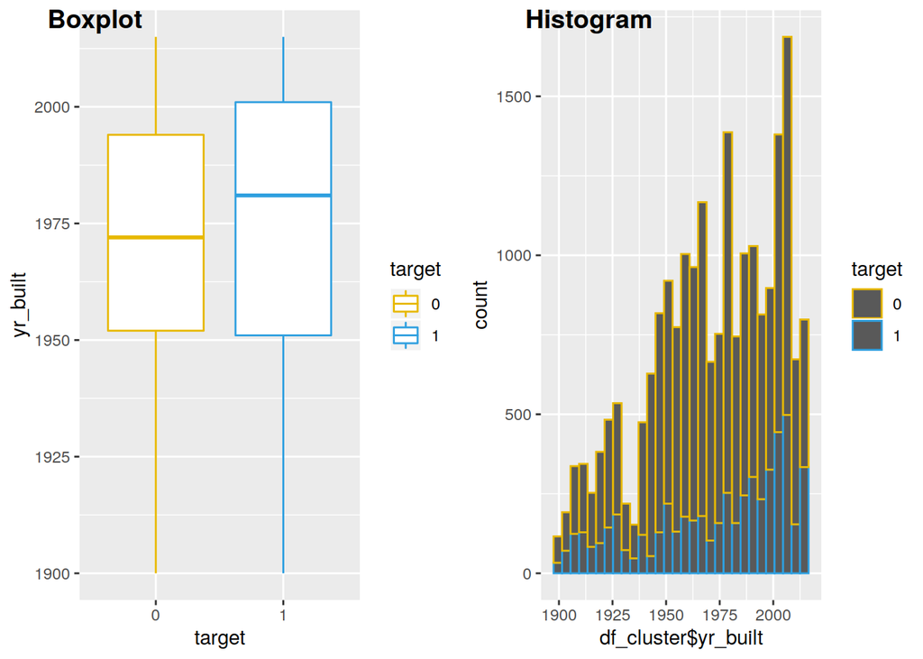

```r
my3cols <- c("#E7B800", "#2E9FDF", "#FC4E07")
df_cluster$target <- as.factor(df_cluster$target)
pBoxPlot <- ggplot(df_cluster, aes(x = target, y = yr_built))
bxp <- pBoxPlot + geom_boxplot(aes(color = target)) +
  scale_color_manual(values = my3cols)
geomHist <- ggplot(data=df_cluster, aes(df_cluster$yr_built))
gh <- geomHist + geom_histogram(aes(color = target)) +
      scale_color_manual(values = my3cols)
figure <- ggarrange(bxp, gh,
                    labels = c("Boxplot", "Histogram"),
                    ncol = 2, nrow = 1)
figure
```

**Estudio de la variable “yr_renovated” (año de renovación de la vivienda).**

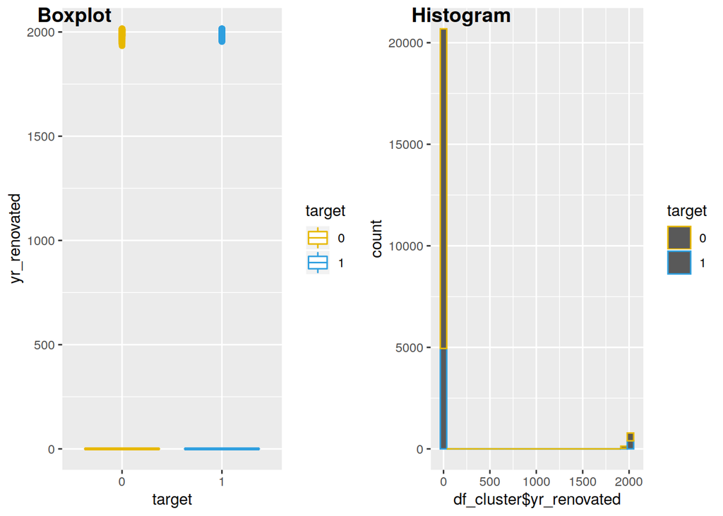

```r
my3cols <- c("#E7B800", "#2E9FDF", "#FC4E07")
df_cluster$target <- as.factor(df_cluster$target)
pBoxPlot <- ggplot(df_cluster, aes(x = target, y = yr_renovated))
bxp <- pBoxPlot + geom_boxplot(aes(color = target)) +
  scale_color_manual(values = my3cols)
geomHist <- ggplot(data=df_cluster, aes(df_cluster$yr_renovated))
gh <- geomHist + geom_histogram(aes(color = target)) +
      scale_color_manual(values = my3cols)
figure <- ggarrange(bxp, gh,
                    labels = c("Boxplot", "Histogram"),
                    ncol = 2, nrow = 1)
figure
```

**Estudio de la variable “bathrooms” (Número de baños/aseos por vivienda):**

```r
var_bathrooms_1 = df_target_1$bathrooms
var_bathrooms_0 = df_target_0$bathrooms

name_1 = "target_1 bathrooms"
name_2 = "target_0 bathrooms"

my3cols <- c("#E7B800", "#2E9FDF", "#FC4E07")
# Tablas de frecuencias en función al mes y al año
summary(var_bathrooms_1)
```

```
##    Min. 1st Qu.  Median    Mean 3rd Qu.    Max.
##   0.750   2.250   2.500   2.675   3.250   8.000
```

```r
summary(var_bathrooms_0)
```

```
##    Min. 1st Qu.  Median    Mean 3rd Qu.    Max.
##   0.500   1.500   2.000   1.931   2.500   7.500
```

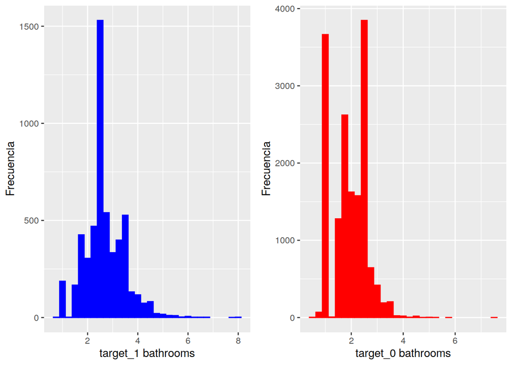

```r
pb1<-ggplot(df_target_1, aes(unlist(var_bathrooms_1), fill=unlist(var_bathrooms_1))) +
  geom_bar(position="dodge", fill='blue', color="blue") +
  labs(x= name_1, y = 'Frecuencia', fill=NULL)

pb2<-ggplot(df_target_0, aes(unlist(var_bathrooms_0), fill=unlist(var_bathrooms_0))) +
  geom_bar(position="dodge", fill='red', color="red") +
  labs(x= name_2, y = 'Frecuencia', fill=NULL)


figure <- ggarrange(pb1, pb2)
figure
```

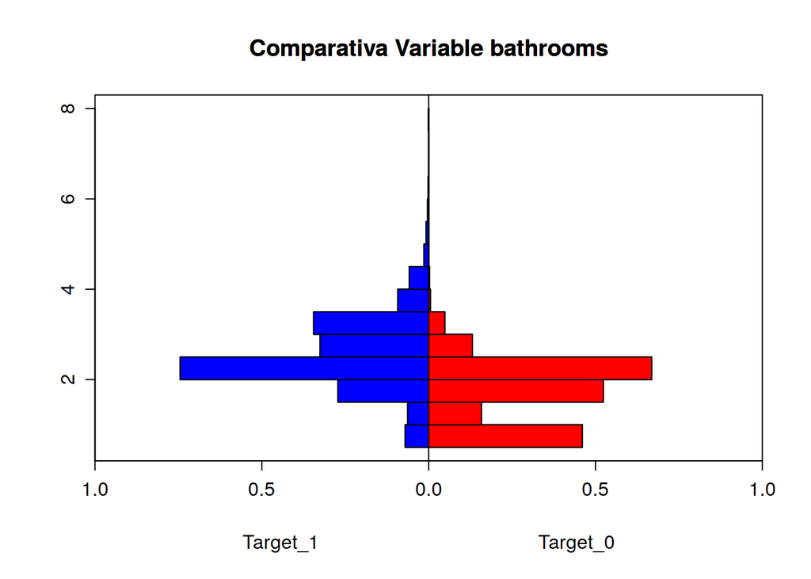

```r
out = histbackback(list(Target_1 = df_cluster %>% filter(target == "1") %>% filter(!is.na(bathrooms)) %>% .$bathrooms,
                        Target_0 = df_cluster %>% filter(target == "0") %>% filter(!is.na(bathrooms)) %>% .$bathrooms),
                   probability = TRUE, main = "Comparativa Variable bathrooms")
# Colorear mitad izquierda y derecha del gráfico
barplot(-out$left, col="blue" , horiz=TRUE, space=0, add=TRUE, axes=FALSE)
barplot(out$right, col="red", horiz=TRUE, space=0, add=TRUE, axes=FALSE)
```

**Estudio de la variable “bedrooms” (Número de habitaciones por vivienda):**

```r
var_bedrooms_1 = df_target_1$bedrooms
var_bedrooms_0 = df_target_0$bedrooms

name_1 = "target_1 bedrooms"
name_2 = "target_0 bedrooms"

my3cols <- c("#E7B800", "#2E9FDF")
# Tablas de frecuencias en función al mes y al año
summary(var_bedrooms_1)
```

```
##    Min. 1st Qu.  Median    Mean 3rd Qu.    Max.
##   1.000   3.000   4.000   3.824   4.000  10.000
```

```r
summary(var_bedrooms_0)
```

```
##    Min. 1st Qu.  Median    Mean 3rd Qu.    Max.
##   1.000   3.000   3.000   3.224   4.000  33.000
```

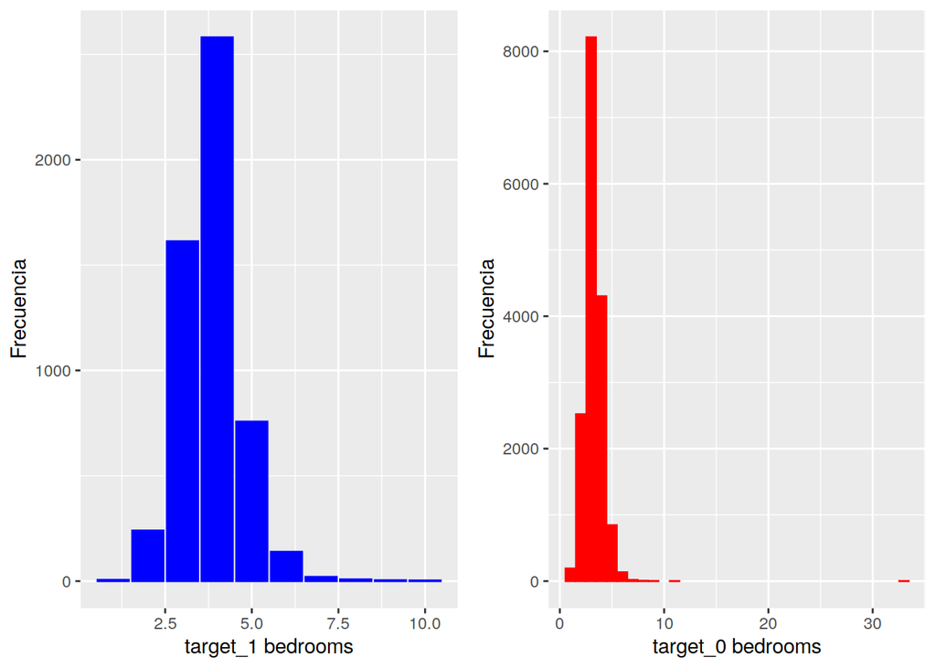

```r
pb1<-ggplot(df_target_1, aes(unlist(var_bedrooms_1), fill=unlist(var_bedrooms_1))) +
  geom_bar(position="dodge", fill='blue', color="blue") +
  labs(x= name_1, y = 'Frecuencia', fill=NULL)

pb2<-ggplot(df_target_0, aes(unlist(var_bedrooms_0), fill=unlist(var_bedrooms_0))) +
  geom_bar(position="dodge", fill='red', color="red") +
  labs(x= name_2, y = 'Frecuencia', fill=NULL)


figure <- ggarrange(pb1, pb2)
figure
```

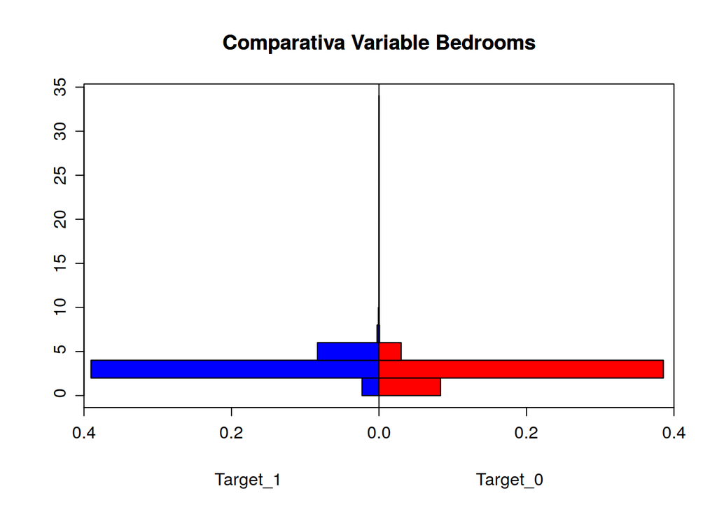

```r
out = histbackback(list(Target_1 = df_cluster %>% filter(target == "1") %>% filter(!is.na(bedrooms)) %>% .$bedrooms,
                        Target_0 = df_cluster %>% filter(target == "0") %>% filter(!is.na(bedrooms)) %>% .$bedrooms),
                   probability = TRUE, main = "Comparativa Variable Bedrooms")
# Colorear mitad izquierda y derecha del gráfico
barplot(-out$left, col="blue" , horiz=TRUE, space=0, add=TRUE, axes=FALSE)
barplot(out$right, col="red", horiz=TRUE, space=0, add=TRUE, axes=FALSE)
```

**Estudio de la variable “floors” (Número de plantas por vivienda):**

```r
var_floors_1 = df_target_1$floors
var_floors_0 = df_target_0$floors

name_1 = "target_1 floors"
name_2 = "target_0 floors"

my3cols <- c("#E7B800", "#2E9FDF")
# Tablas de frecuencias en función al mes y al año
summary(var_floors_1)
```

```
##    Min. 1st Qu.  Median    Mean 3rd Qu.    Max.
##   1.000   1.000   2.000   1.713   2.000   3.500
```

```r
summary(var_floors_0)
```

```
##    Min. 1st Qu.  Median    Mean 3rd Qu.    Max.
##   1.000   1.000   1.000   1.422   2.000   3.500
```

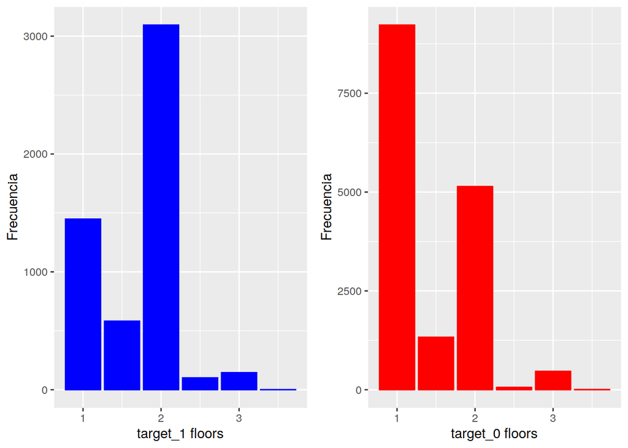

```r
pb1<-ggplot(df_target_1, aes(unlist(var_floors_1), fill=unlist(var_floors_1))) +
  geom_bar(position="dodge", fill='blue', color="blue") +
  labs(x= name_1, y = 'Frecuencia', fill=NULL)

pb2<-ggplot(df_target_0, aes(unlist(var_floors_0), fill=unlist(var_floors_0))) +
  geom_bar(position="dodge", fill='red', color="red") +
  labs(x= name_2, y = 'Frecuencia', fill=NULL)


figure <- ggarrange(pb1, pb2)
figure
```

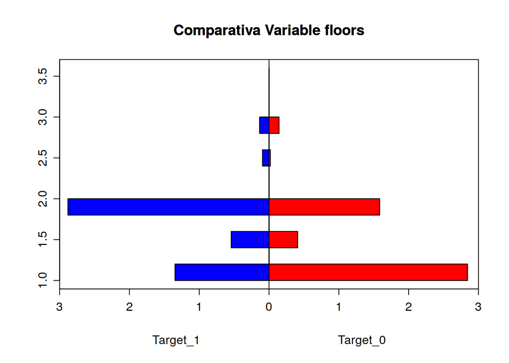

```r
out = histbackback(list(Target_1 = df_cluster %>% filter(target == "1") %>% filter(!is.na(floors)) %>% .$floors,
                        Target_0 = df_cluster %>% filter(target == "0") %>% filter(!is.na(floors)) %>% .$floors),
                   probability = TRUE, main = "Comparativa Variable floors")
# Colorear mitad izquierda y derecha del gráfico
barplot(-out$left, col="blue" , horiz=TRUE, space=0, add=TRUE, axes=FALSE)
barplot(out$right, col="red", horiz=TRUE, space=0, add=TRUE, axes=FALSE)
```

**Estudio de la variable “condition” (estado de la vivienda del 1 al 5):**

```r
var_condition_1 = df_target_1$condition
var_condition_0 = df_target_0$condition

name_1 = "target_1 condition"
name_2 = "target_1 condition"

my3cols <- c("#E7B800", "#2E9FDF")
# Tablas de frecuencias en función al mes y al año
summary(var_condition_1)
```

```
##    Min. 1st Qu.  Median    Mean 3rd Qu.    Max.
##   1.000   3.000   3.000   3.462   4.000   5.000
```

```r
summary(var_condition_0)
```

```
##    Min. 1st Qu.  Median    Mean 3rd Qu.    Max.
##   1.000   3.000   3.000   3.393   4.000   5.000
```

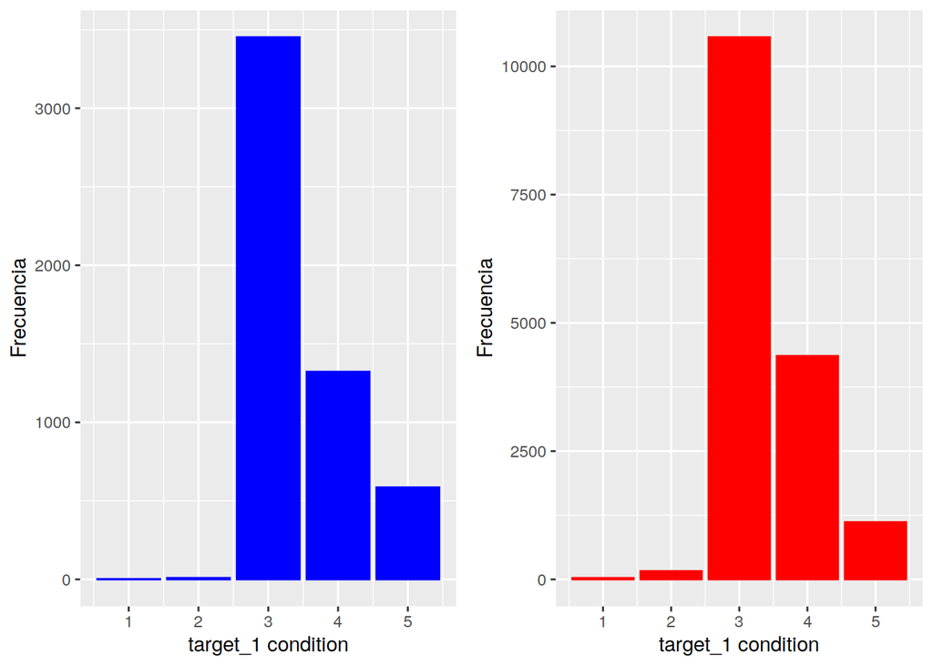

```r
pb1<-ggplot(df_target_1, aes(unlist(var_condition_1), fill=unlist(var_condition_1))) +
  geom_bar(position="dodge", fill='blue', color="blue") +
  labs(x= name_1, y = 'Frecuencia', fill=NULL)

pb2<-ggplot(df_target_0, aes(unlist(var_condition_0), fill=unlist(var_condition_0))) +
  geom_bar(position="dodge", fill='red', color="red") +
  labs(x= name_2, y = 'Frecuencia', fill=NULL)


figure <- ggarrange(pb1, pb2)
figure
```

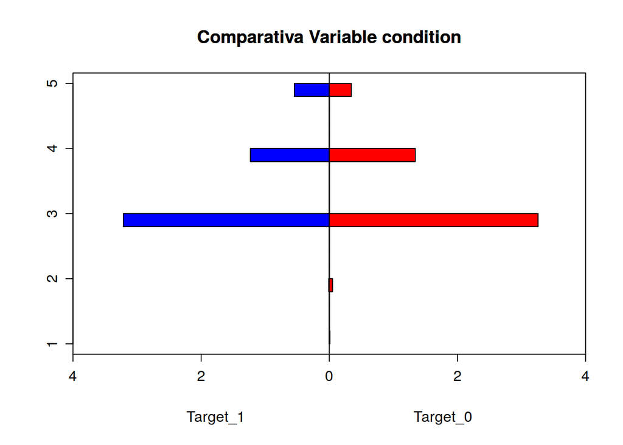

```r
out = histbackback(list(Target_1 = df_cluster %>% filter(target == "1") %>% filter(!is.na(condition)) %>% .$condition,
                        Target_0 = df_cluster %>% filter(target == "0") %>% filter(!is.na(condition)) %>% .$condition),
                   probability = TRUE, main = "Comparativa Variable condition")
# Colorear mitad izquierda y derecha del gráfico
barplot(-out$left, col="blue" , horiz=TRUE, space=0, add=TRUE, axes=FALSE)
barplot(out$right, col="red", horiz=TRUE, space=0, add=TRUE, axes=FALSE)
```

**Estudio de la variable “waterfront” (viviendas frente a grandes masas de agua):**

```r
var_waterfront_1 = df_target_1$waterfront
var_waterfront_0 = df_target_0$waterfront

name_1 = "target_1 waterfront"
name_2 = "target_0 waterfront"

my3cols <- c("#E7B800", "#2E9FDF")
# Tablas de frecuencias en función al mes y al año
summary(var_waterfront_1)
```

```
##    Min. 1st Qu.  Median    Mean 3rd Qu.    Max.
## 0.00000 0.00000 0.00000 0.02514 0.00000 1.00000
```

```r
summary(var_waterfront_0)
```

```
##     Min.  1st Qu.   Median     Mean  3rd Qu.     Max.
## 0.000000 0.000000 0.000000 0.001726 0.000000 1.000000
```

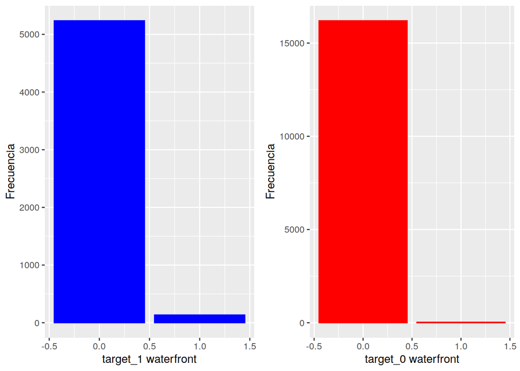

```r
pb1<-ggplot(df_target_1, aes(unlist(var_waterfront_1), fill=unlist(var_waterfront_1))) +
  geom_bar(position="dodge", fill='blue', color="blue") +
  labs(x= name_1, y = 'Frecuencia', fill=NULL)

pb2<-ggplot(df_target_0, aes(unlist(var_waterfront_0), fill=unlist(var_waterfront_0))) +
  geom_bar(position="dodge", fill='red', color="red") +
  labs(x= name_2, y = 'Frecuencia', fill=NULL)
figure <- ggarrange(pb1, pb2)
figure
```

**Estudio de la variable “grade” (nota general de la vivienda del 1 al 13):**

```r
var_grade_1 = df_target_1$grade
var_grade_0 = df_target_0$grade

name_1 = "target_1 grade"
name_2 = "target_0 grade"

my3cols <- c("#E7B800", "#2E9FDF")
# Tablas de frecuencias en función al mes y al año
summary(var_grade_1)
```

```
##    Min. 1st Qu.  Median    Mean 3rd Qu.    Max.
##   5.000   8.000   9.000   8.844  10.000  13.000
```

```r
summary(var_grade_0)
```

```
##    Min. 1st Qu.  Median    Mean 3rd Qu.    Max.
##   3.000   7.000   7.000   7.265   8.000  11.000
```

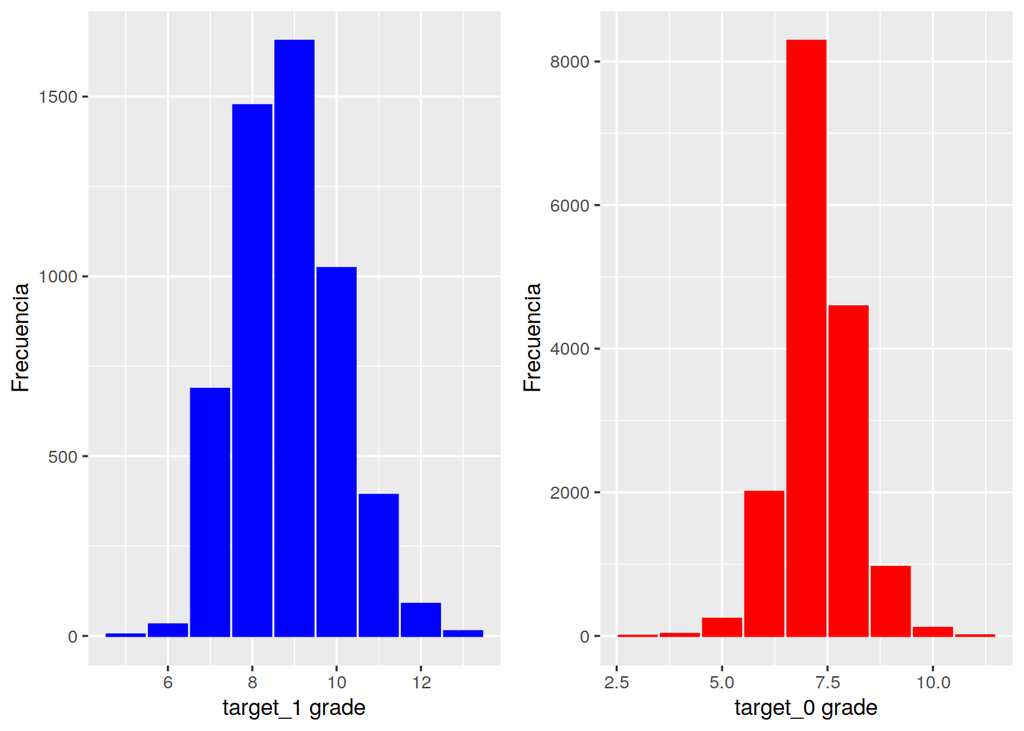

```r
pb1<-ggplot(df_target_1, aes(unlist(var_grade_1), fill=unlist(var_grade_1))) +
  geom_bar(position="dodge", fill='blue', color="blue") +
  labs(x= name_1, y = 'Frecuencia', fill=NULL)

pb2<-ggplot(df_target_0, aes(unlist(var_grade_0), fill=unlist(var_grade_0))) +
  geom_bar(position="dodge", fill='red', color="red") +
  labs(x= name_2, y = 'Frecuencia', fill=NULL)

figure <- ggarrange(pb1, pb2)
figure
```

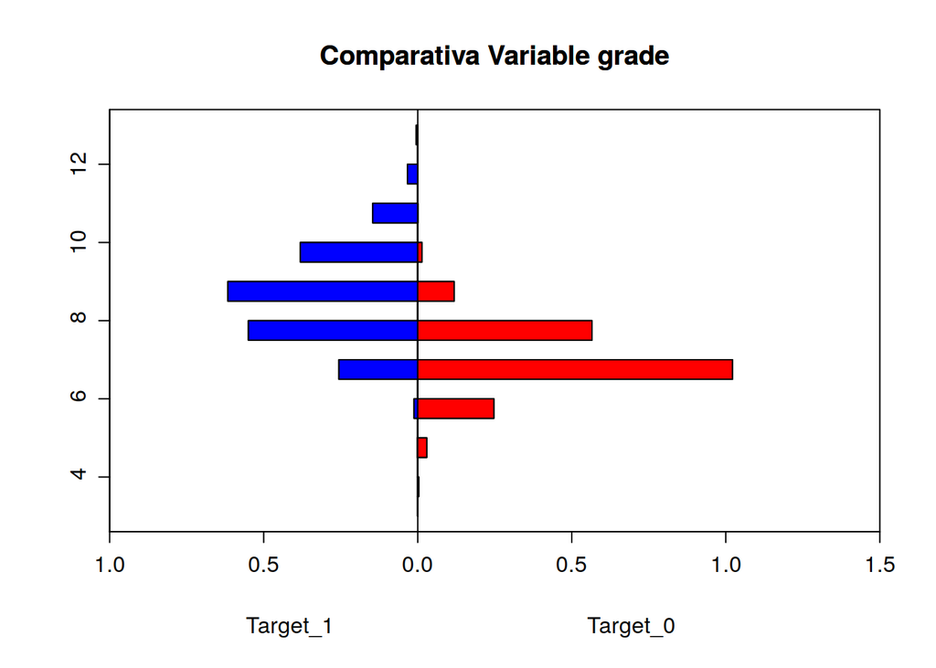

```r
out = histbackback(list(Target_1 = df_cluster %>% filter(target == "1") %>% filter(!is.na(grade)) %>% .$grade,
                        Target_0 = df_cluster %>% filter(target == "0") %>% filter(!is.na(grade)) %>% .$grade),
                   probability = TRUE, main = "Comparativa Variable grade")
# Colorear mitad izquierda y derecha del gráfico
barplot(-out$left, col="blue" , horiz=TRUE, space=0, add=TRUE, axes=FALSE)
barplot(out$right, col="red", horiz=TRUE, space=0, add=TRUE, axes=FALSE)
```

**Estudio de la variable “view” (número de visitas que ha recibido la vivienda):**

```r
var_view_1 = df_target_1$view
var_view_0 = df_target_0$view

name_1 = "target_1 view"
name_2 = "target_0 view"
my3cols <- c("#E7B800", "#2E9FDF")
# Tablas de frecuencias en función al mes y al año
summary(var_view_1)
```

```
##    Min. 1st Qu.  Median    Mean 3rd Qu.    Max.
##  0.0000  0.0000  0.0000  0.6258  0.0000  4.0000
```

```r
summary(var_view_0)
```

```
##    Min. 1st Qu.  Median    Mean 3rd Qu.    Max.
##  0.0000  0.0000  0.0000  0.1047  0.0000  4.0000
```

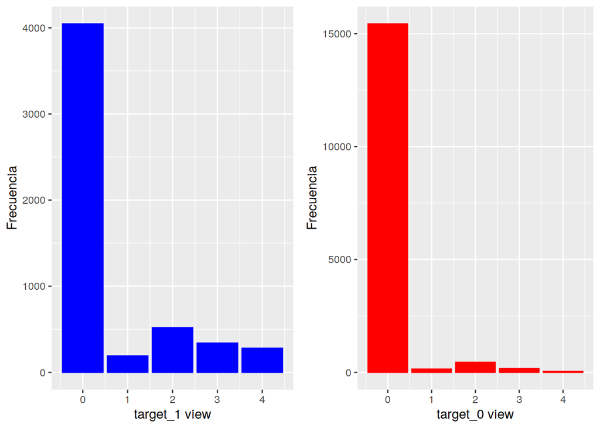

```r
pb1<-ggplot(df_target_1, aes(unlist(var_view_1), fill=unlist(var_view_1))) +
  geom_bar(position="dodge", fill='blue', color="blue") +
  labs(x= name_1, y = 'Frecuencia', fill=NULL)

pb2<-ggplot(df_target_0, aes(unlist(var_view_0), fill=unlist(var_view_0))) +
  geom_bar(position="dodge", fill='red', color="red") +
  labs(x= name_2, y = 'Frecuencia', fill=NULL)




figure <- ggarrange(pb1, pb2)
figure
```

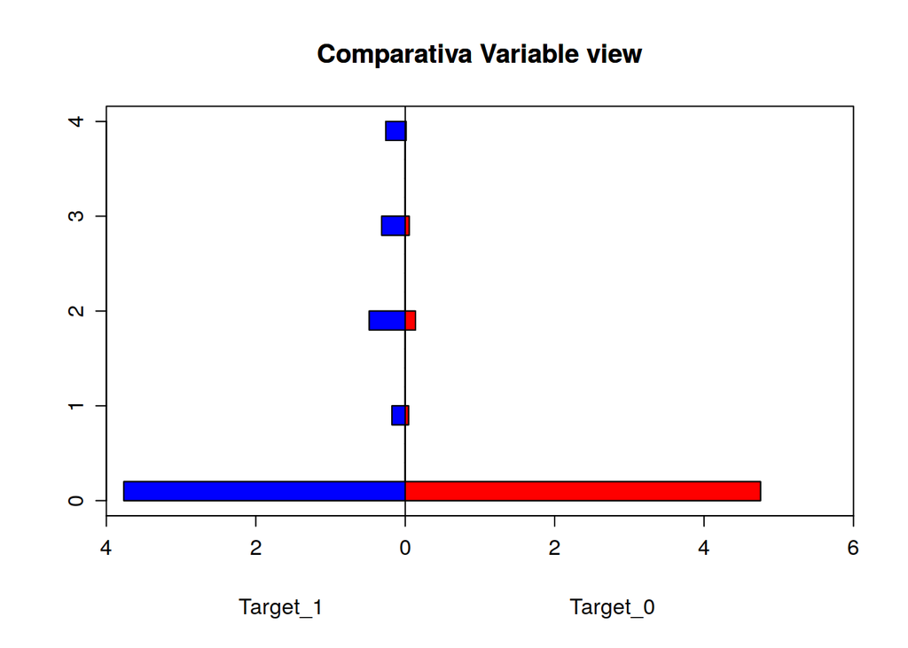

```r
out = histbackback(list(Target_1 = df_cluster %>% filter(target == "1") %>% filter(!is.na(view)) %>% .$view,
                        Target_0 = df_cluster %>% filter(target == "0") %>% filter(!is.na(view)) %>% .$view),
                   probability = TRUE, main = "Comparativa Variable view")
# Colorear mitad izquierda y derecha del gráfico
barplot(-out$left, col="blue" , horiz=TRUE, space=0, add=TRUE, axes=FALSE)
barplot(out$right, col="red", horiz=TRUE, space=0, add=TRUE, axes=FALSE)
```

```r
summary (df_cluster)
```

```
##       X.2             X.1              X                  Y
##  Min.   :    1   Min.   :    1   Min.   :-30.6010   Min.   :-28.84906
##  1st Qu.: 5400   1st Qu.: 5400   1st Qu.: -7.3212   1st Qu.:-12.29488
##  Median :10799   Median :10799   Median :  0.2695   Median :  0.09209
##  Mean   :10799   Mean   :10799   Mean   :  0.0000   Mean   :  0.00000
##  3rd Qu.:16198   3rd Qu.:16198   3rd Qu.:  8.5906   3rd Qu.: 11.16195
##  Max.   :21597   Max.   :21597   Max.   : 27.5371   Max.   : 30.13228
##
##        id                   date           price            bedrooms
##  Min.   :1.000e+06   6/23/2014:  142   Min.   :  78000   Min.   : 1.000
##  1st Qu.:2.123e+09   6/25/2014:  131   1st Qu.: 322000   1st Qu.: 3.000
##  Median :3.905e+09   6/26/2014:  131   Median : 450000   Median : 3.000
##  Mean   :4.580e+09   7/8/2014 :  127   Mean   : 540297   Mean   : 3.373
##  3rd Qu.:7.309e+09   4/27/2015:  126   3rd Qu.: 645000   3rd Qu.: 4.000
##  Max.   :9.900e+09   3/25/2015:  123   Max.   :7700000   Max.   :33.000
##                      (Other)  :20817
##    bathrooms      sqft_living       sqft_lot           floors
##  Min.   :0.500   Min.   :  370   Min.   :    520   Min.   :1.000
##  1st Qu.:1.750   1st Qu.: 1430   1st Qu.:   5040   1st Qu.:1.000
##  Median :2.250   Median : 1910   Median :   7618   Median :1.500
##  Mean   :2.116   Mean   : 2080   Mean   :  15099   Mean   :1.494
##  3rd Qu.:2.500   3rd Qu.: 2550   3rd Qu.:  10685   3rd Qu.:2.000
##  Max.   :8.000   Max.   :13540   Max.   :1651359   Max.   :3.500
##
##    waterfront            view          condition        grade
##  Min.   :0.000000   Min.   :0.0000   Min.   :1.00   Min.   : 3.000
##  1st Qu.:0.000000   1st Qu.:0.0000   1st Qu.:3.00   1st Qu.: 7.000
##  Median :0.000000   Median :0.0000   Median :3.00   Median : 7.000
##  Mean   :0.007547   Mean   :0.2343   Mean   :3.41   Mean   : 7.658
##  3rd Qu.:0.000000   3rd Qu.:0.0000   3rd Qu.:4.00   3rd Qu.: 8.000
##  Max.   :1.000000   Max.   :4.0000   Max.   :5.00   Max.   :13.000
##
##    sqft_above   sqft_basement       yr_built     yr_renovated
##  Min.   : 370   Min.   :   0.0   Min.   :1900   Min.   :   0.00
##  1st Qu.:1190   1st Qu.:   0.0   1st Qu.:1951   1st Qu.:   0.00
##  Median :1560   Median :   0.0   Median :1975   Median :   0.00
##  Mean   :1789   Mean   : 291.7   Mean   :1971   Mean   :  84.46
##  3rd Qu.:2210   3rd Qu.: 560.0   3rd Qu.:1997   3rd Qu.:   0.00
##  Max.   :9410   Max.   :4820.0   Max.   :2015   Max.   :2015.00
##
```

[output cut: 9 more lines]

```
##  Min.   :   651   0:16226   1      :4630   low:9970
##  1st Qu.:  5100   1: 5371   9      :3110   med:8225
##  Median :  7620             3      :2859   top:3402
##  Mean   : 12758             8      :2370
##  3rd Qu.: 10083             5      :2230
##  Max.   :871200             7      :1962
##                             (Other):4436
##  cluster_final      target
##  Length:21597       0:16226
##  Class :character   1: 5371
##  Mode  :character
##
##
##
##
```

# Correlaciones

En e siguiente gráfico descritivo vemos que apraecen altas y medias correlaciones entre algunas variables por lo que vamos a tener que realizar un trabajo con las mismas con Ridge y Lasso.

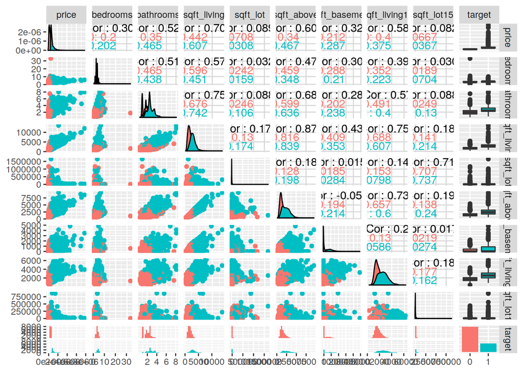

```r
pm <- ggpairs(
  df_cluster[, c( 7,8,9,10,11,17,18,24,25,30)],
  ggplot2::aes(colour=target))
pm
```

# Creación Base Train y Control

Definimos una semilla aleatoria y realizamos una partición en Train 70% y Test 30%.

```r
set.seed(737)
inTraining <- createDataPartition(df_cluster$id, p = .7, list = FALSE)
train    <- df_cluster[inTraining,]
control  <- df_cluster[-inTraining,]


table(train$target)
```

```
##
##     0     1
## 11372  3748
```

```r
table(control$target)
```

```
##
##    0    1
## 4854 1623
```

# Ridge regression

Intenta minimizar el RSS, ridge regression incorpora un término llamado shrinkage penalty que fuerza a que los coeficientes de los predictores tiendan a cero controlada por el parámetro λ. Cuando λ=0 la penalización es nula y los resultados son equivalentes a los obtenidos por mínimos cuadrados, cuando λ=∞ todos los coeficientes son cero. La principal ventaja es la reducción de Varianza. Si todos los predictores incluidos tienen coeficientes diferentes a cero (todos contribuyen al modelo) y aproximadamente de la misma magnitud, ridge regression tiende a funcionar mejor.

Para realizar ridge regression se va a emplear la función glmnet() del paquete glmnet.

```r
#matriz con las valores de los predictores para cada observación y un vector y=target variable respuesta
x <- model.matrix(target~  (bedrooms+ bathrooms+floors+sqft_living+grade+condition+view+waterfront+                           sqft_lot+sqft_above+sqft_basement+yr_built+yr_renovated+yr_renovated+
                            sqft_living15+sqft_lot15+Cluster_final), data = train)[, -1]
head(x)
```

```
##   bedrooms bathrooms floors sqft_living grade condition view waterfront
## 1        3      1.00      1        1180     7         3    0          0
## 2        3      2.25      2        2570     7         3    0          0
## 3        2      1.00      1         770     6         3    0          0
## 4        4      3.00      1        1960     7         5    0          0
## 5        3      2.00      1        1680     8         3    0          0
## 6        4      4.50      1        5420    11         3    0          0
##   sqft_lot sqft_above sqft_basement yr_built yr_renovated sqft_living15
## 1     5650       1180             0     1955            0          1340
## 2     7242       2170           400     1951         1991          1690
## 3    10000        770             0     1933            0          2720
## 4     5000       1050           910     1965            0          1360
## 5     8080       1680             0     1987            0          1800
## 6   101930       3890          1530     2001            0          4760
##   sqft_lot15 Cluster_finalmed Cluster_finaltop
## 1       5650                0                0
## 2       7639                0                1
## 3       8062                1                0
## 4       5000                0                0
## 5       7503                1                0
## 6     101930                1                0
```

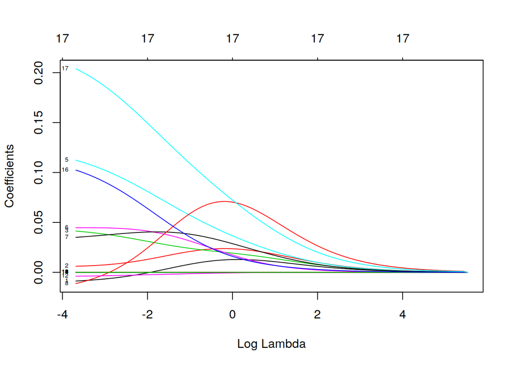

```r
y <- train$target
y <- as.integer(y)



# Para obtener un ajuste mediante ridge regression se indica argumento alpha=0.
modelos_ridge <- glmnet(x = x, y = y, alpha = 0)
plot(modelos_ridge, xvar = "lambda", label = TRUE)
```

Al aumentar el tamaño de los Lambda dismunuyen los coeficientes. Con el fin de identificar el valor de λ que da lugar al mejor modelo, se puede recurrir a Cross-Validation. La función cv.glmnet() calcula el cv-test-error, utilizando por defecto k=10.

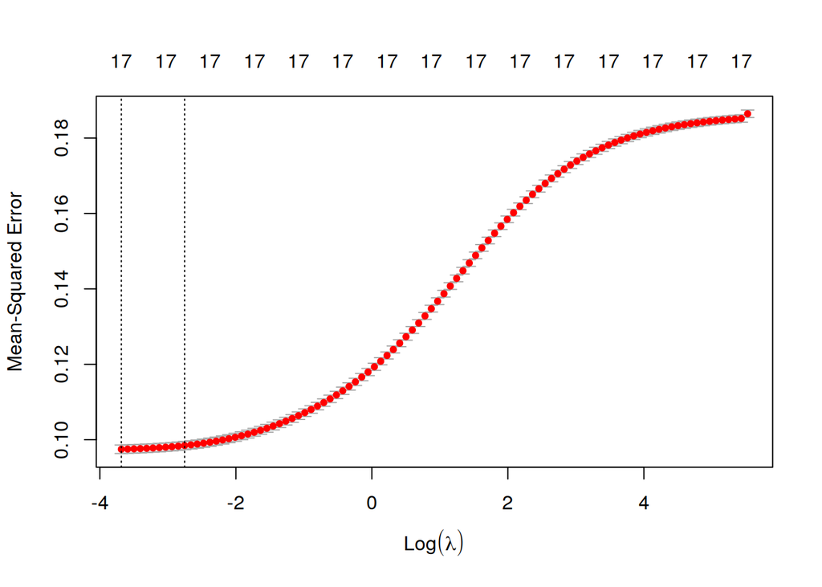

```r
set.seed(737)
cv_error_ridge <- cv.glmnet(x = x, y = y, alpha = 0, nfolds = 15,
                            type.measure = "mse")
plot(cv_error_ridge)
```

Podemos observar cómo varía el error cuadrático medio, en función del valor de regularización. Gráficamente se comprueba que el error no aumenta hasta que las variables con coeficiente mayor que cero es menor que -2, pero el menor error cuadrático medio se da para 17 variables regresoras y se mantiene constante. Es una de las grandes diferencias con Lasso.

```r
# Valor lambda con el que se consigue el mínimo test-error
cv_error_ridge$lambda.min
```

```
## [1] 0.02511189
```

```r
# Valor lambda óptimo: mayor valor de lambda con el que el test-error no se
# aleja más de 1 sd del mínimo test-error posible.
cv_error_ridge$lambda.1se
```

```
## [1] 0.0636678
```

```r
# Se muestra el valor de los coeficientes para el valor de lambda óptimo

modelo_final_ridge <- glmnet(x = x, y = y, alpha = 0, lambda = cv_error_ridge$lambda.1se)
coef(modelo_final_ridge)
```

```
## 18 x 1 sparse Matrix of class "dgCMatrix"
##                             s0
## (Intercept)       6.148178e+00
## bedrooms         -5.471797e-03
## bathrooms         8.567079e-03
## floors            3.667801e-02
## sqft_living       5.356428e-05
## grade             9.743599e-02
## condition         4.423304e-02
## view              3.822962e-02
## waterfront        3.053282e-03
## sqft_lot          1.126386e-07
## sqft_above        5.519841e-05
## sqft_basement     3.895933e-05
## yr_built         -3.201487e-03
## yr_renovated     -2.591264e-05
## sqft_living15     8.717207e-05
## sqft_lot15       -3.510281e-07
## Cluster_finalmed  8.472668e-02
## Cluster_finaltop  1.782828e-01
```

# Lasso

El método lasso, al igual que ridge regression, fuerza a que las estimaciones de los coeficientes de los predictores tiendan a cero. La diferencia es que lasso sí es capaz de fijar algunos de ellos exactamente a cero, lo que permite además de reducir la varianza, realizar selección de predictores. ∑i=1n(yi−β0−∑j=1pβjxij)2+λ∑j=1p|βj|=RSS+λ∑j=1p|βj|

Cuando solo un pequeño número de predictores de entre todos los incluidos tienen coeficientes sustanciales y el resto tienen valores muy pequeños o iguales a cero, lasso genera mejores modelos.

Selección del tunning parameter λ

Determinar el grado de penalización, seleccionamos un rango de valores de λ y se estima el cross-validation error resultante para cada uno, finalmente se selecciona el valor de λ para el que el error es menor y se ajusta de nuevo el modelo, esta vez empleando todas las observaciones.

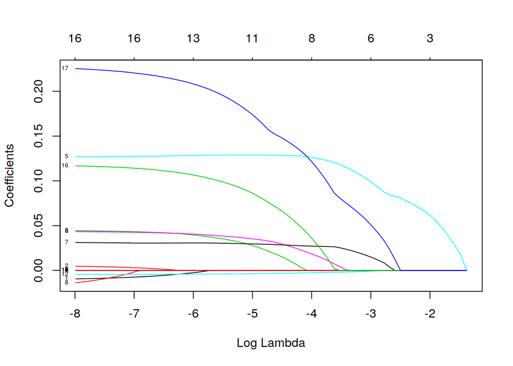

```r
modelos_lasso <- glmnet(x = x, y = y, alpha = 1)
plot(modelos_lasso, xvar = "lambda", label = TRUE)
```

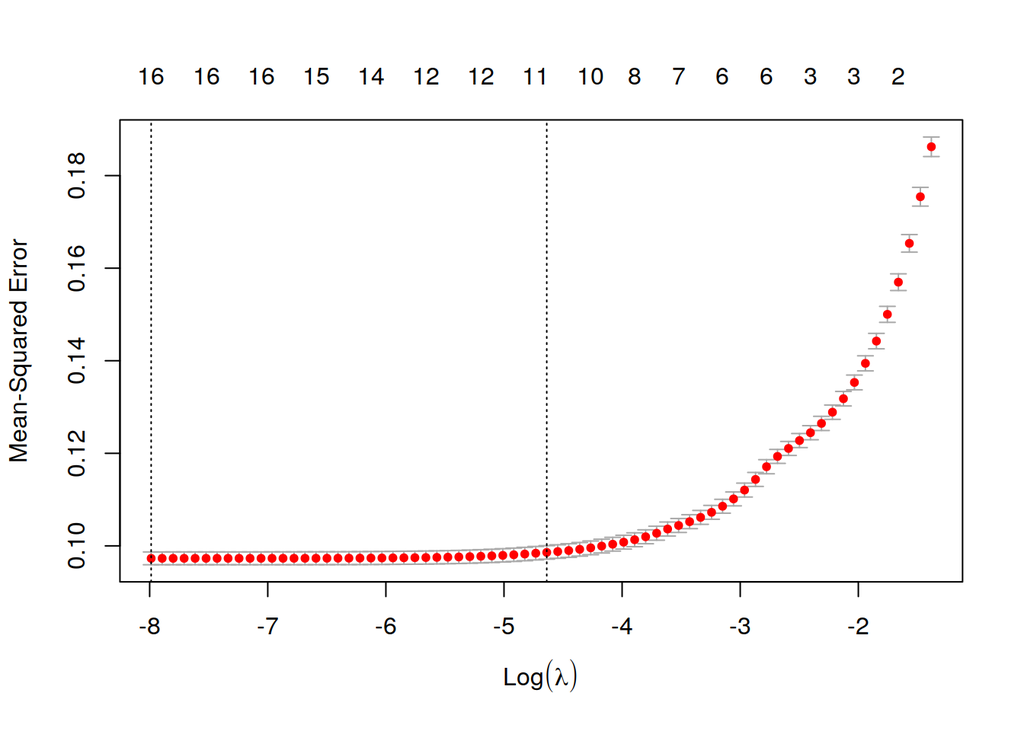

```r
set.seed(737)
cv_error_lasso <- cv.glmnet(x = x, y = y, alpha = 1, nfolds = 10)
plot(cv_error_lasso)
```

```r
cv_error_lasso$lambda.min
```

```
## [1] 0.0003397759
```

```r
cv_error_lasso$lambda.1se
```

```
## [1] 0.00967694
```

```r
# Se reajusta el modelo con todas las observaciones empleando el valor de
# lambda óptimo

modelo_final_lasso <- glmnet(x = x, y = y, alpha = 1, lambda = cv_error_lasso$lambda.1se)
coef(modelo_final_lasso)
```

```
## 18 x 1 sparse Matrix of class "dgCMatrix"
##                             s0
## (Intercept)       6.347292e+00
## bedrooms          .
## bathrooms         .
## floors            1.889468e-02
## sqft_living       8.173068e-05
## grade             1.285092e-01
## condition         3.171024e-02
## view              2.888747e-02
## waterfront        .
## sqft_lot          .
## sqft_above        8.411154e-06
## sqft_basement     .
## yr_built         -3.359509e-03
## yr_renovated      .
## sqft_living15     8.007803e-05
## sqft_lot15        .
## Cluster_finalmed  7.234704e-02
## Cluster_finaltop  1.528256e-01
```

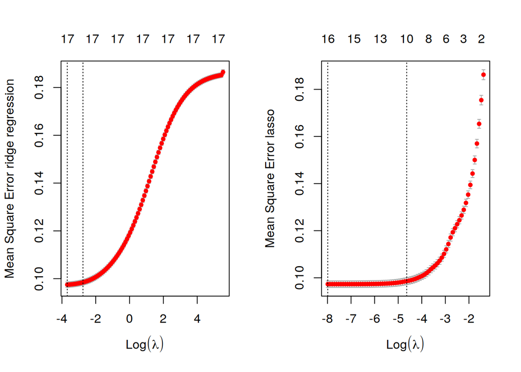

```r
par(mfrow = c(1,2))
plot(cv_error_ridge,ylab = "Mean Square Error ridge regression" )
abline(h = 120000)
plot(cv_error_lasso,ylab = "Mean Square Error lasso")
abline(h = 120000)
```

```r
par(mfrow = c(1,1))
```

# Regresión Logistica

```r
train_glm1 = glm(target ~ floors + grade + condition + view + sqft_above + yr_built + sqft_living15 + Cluster_final ,
               family = binomial,
               data = train )
summary(train_glm1)
```

```
##
## Call:
## glm(formula = target ~ floors + grade + condition + view + sqft_above +
##     yr_built + sqft_living15 + Cluster_final, family = binomial,
##     data = train)
##
## Deviance Residuals:
##     Min       1Q   Median       3Q      Max
## -3.3036  -0.4195  -0.2070  -0.0316   3.4305
##
## Coefficients:
##                    Estimate Std. Error z value Pr(>|z|)
## (Intercept)       6.942e+01  2.633e+00  26.365  < 2e-16 ***
## floors            3.791e-01  7.023e-02   5.398 6.74e-08 ***
## grade             1.418e+00  4.564e-02  31.059  < 2e-16 ***
## condition         5.827e-01  4.755e-02  12.255  < 2e-16 ***
## view              2.347e-01  3.512e-02   6.684 2.32e-11 ***
## sqft_above        8.146e-04  6.281e-05  12.969  < 2e-16 ***
## yr_built         -4.494e-02  1.412e-03 -31.841  < 2e-16 ***
## sqft_living15     7.530e-04  6.477e-05  11.625  < 2e-16 ***
## Cluster_finalmed  1.501e+00  7.369e-02  20.374  < 2e-16 ***
## Cluster_finaltop  1.519e+00  8.415e-02  18.046  < 2e-16 ***
## ---
## Signif. codes:  0 '***' 0.001 '**' 0.01 '*' 0.05 '.' 0.1 ' ' 1
##
## (Dispersion parameter for binomial family taken to be 1)
##
##     Null deviance: 16934.3  on 15119  degrees of freedom
## Residual deviance:  8482.4  on 15110  degrees of freedom
## AIC: 8502.4
##
## Number of Fisher Scoring iterations: 6
```

Viendo los resultados de la regresión logística podemos afirmar que todas las variables introducidas en el modelo son significativas a nivel estadístico, aunque podemos apreciar en las variables Floors y View un valor del estadísitico no demasiado alto lo cual nos dice que no son especialmete explicativas.

### Vamos a probar un modelo Nuevo Versión 2 excluyendo estas variables

```r
train_glm2 = update(train_glm1, . ~ . - view - floors) # Eliminamos dos predictores
anova(train_glm2, train_glm1, test = "Chisq")
```

```
## Analysis of Deviance Table
##
## Model 1: target ~ grade + condition + sqft_above + yr_built + sqft_living15 +
##     Cluster_final
## Model 2: target ~ floors + grade + condition + view + sqft_above + yr_built +
##     sqft_living15 + Cluster_final
##   Resid. Df Resid. Dev Df Deviance  Pr(>Chi)
## 1     15112     8557.1
## 2     15110     8482.4  2   74.649 < 2.2e-16 ***
## ---
## Signif. codes:  0 '***' 0.001 '**' 0.01 '*' 0.05 '.' 0.1 ' ' 1
```

Esta salida nos dice que el ajuste es estadísticamente significativo pero a nivel negocio son importantes y en el primer modelo eran significativas por lo que las vamos a mantener.

```r
head(predict(train_glm1, type = "response")) # Probabilidades en escala de la salida
```

```
##          1          2          3          4          5          6
## 0.01185521 0.21829089 0.06628206 0.02192549 0.10077379 0.99578048
```

```r
summary(train_glm1$fitted.values)
```

```
##      Min.   1st Qu.    Median      Mean   3rd Qu.      Max.
## 0.0000497 0.0206947 0.0774001 0.2478836 0.3735923 1.0000000
```